# Introduction to networks

## Networks

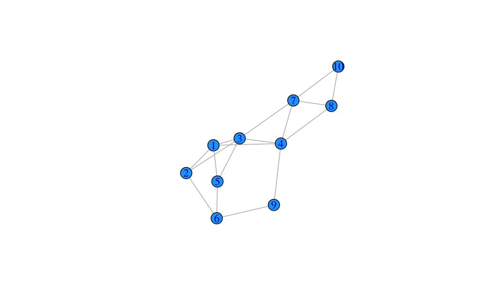

```r
library(igraph)
plot(barabasi.game(10, m=2, directed=FALSE),
    vertex.color='dodgerblue')
```

## Types of networks

Social networks

Gene reg or expression networks

Transportation networks

Computer networks

Ecological networks (host-parasite, plant-pollinator)

Movie-actor networks

Spatial networks

…any interaction, flow, or association

## Directed/undirected

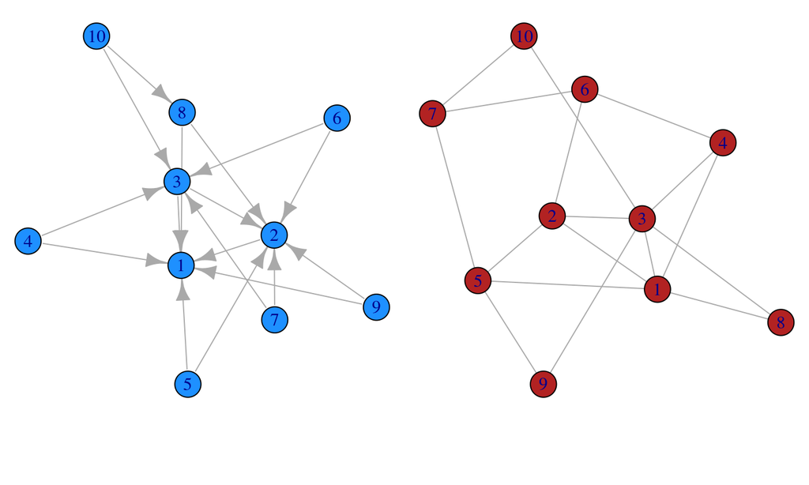

```r
par(layout(matrix(1:2, ncol=2)), mar=c(3,0,0,0))
plot(barabasi.game(10, m=2, directed=TRUE),
    vertex.color='dodgerblue', vertex.labels=NA)
plot(barabasi.game(10, m=2, directed=FALSE),
    vertex.color='firebrick', vertex.labels=NA)
```

## Weighted/unweighted

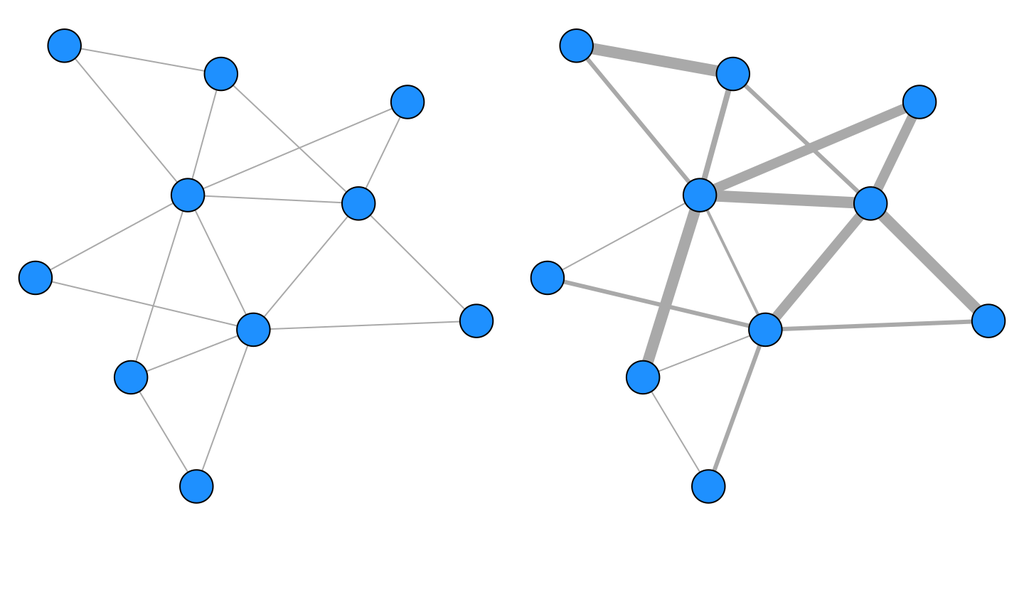

## Unipartite/bipartite

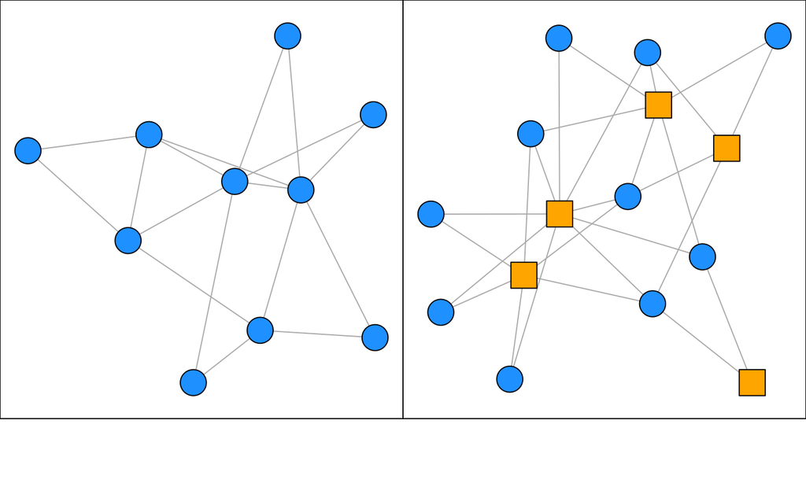

## Network visualization

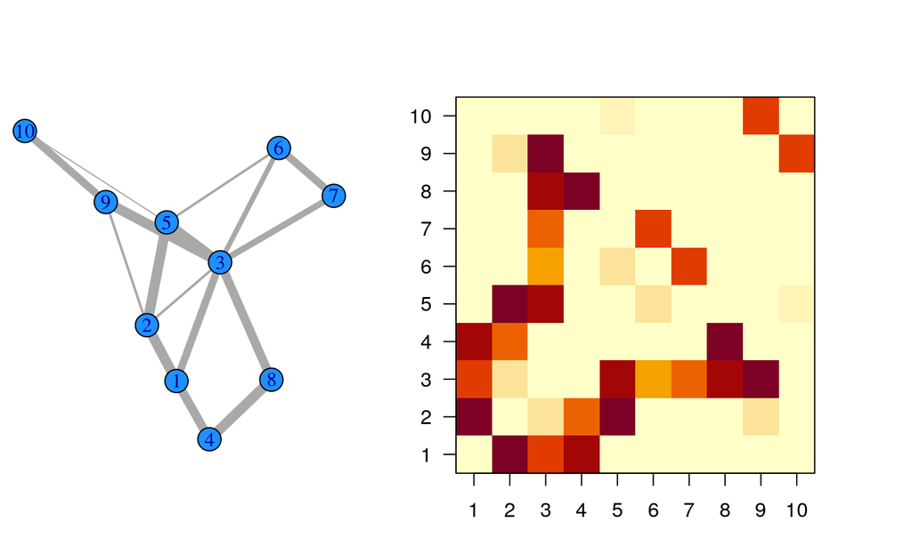

## Network-level measures

**Nestedness**:

Tendency of interactions to form proper subsets of interactions

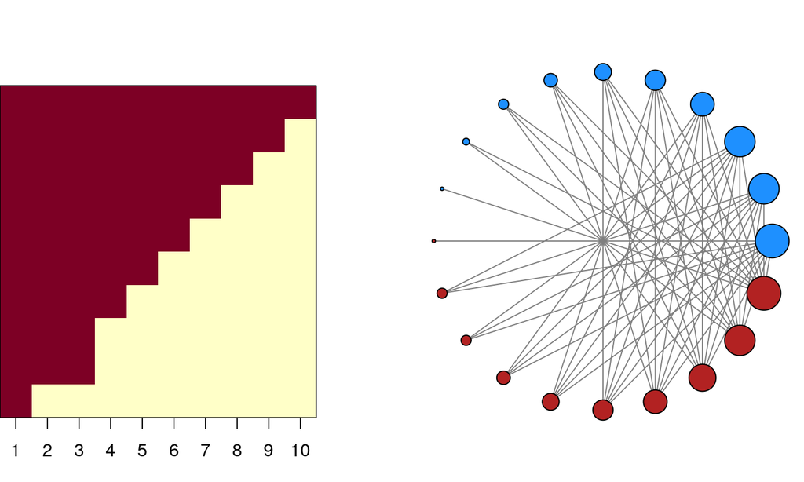

## Network-level measures

**Modularity**:

Tendency of interactions to occur within cliques or communities

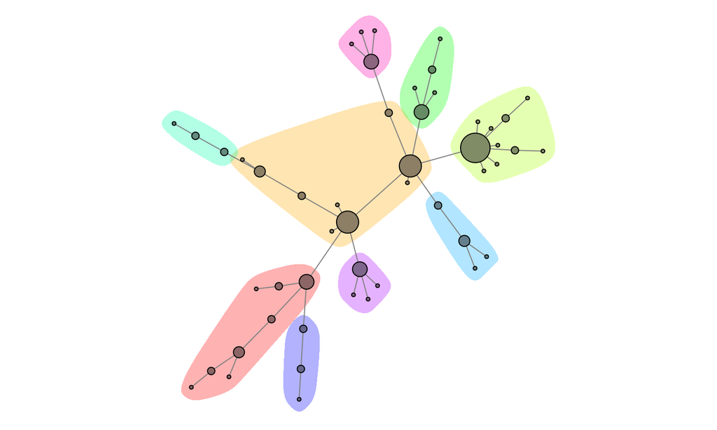

## Network-level measures

**Degree distribution**:

The relative distribution of edges per node.

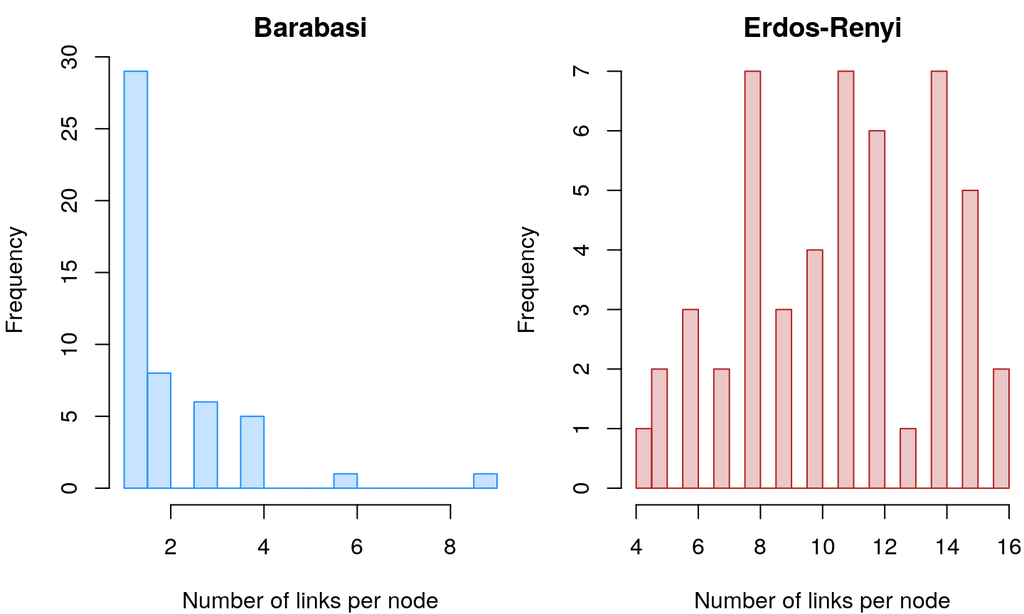

## Node-level measures

**Degree** :

The number of edges per node. A form of *centrality*.

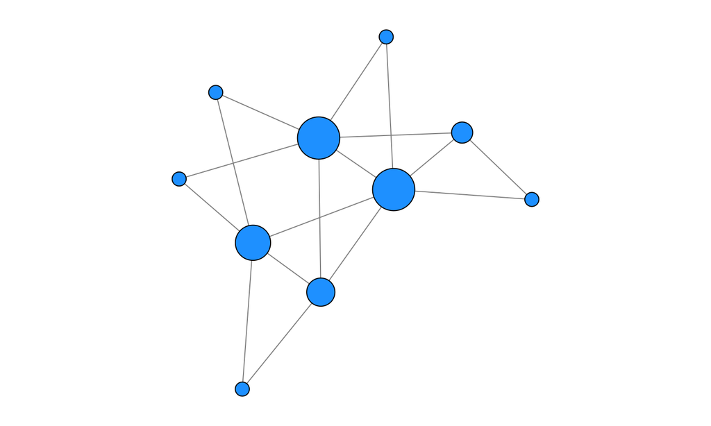

## Node-level measures

**Betweenness**:

The number of shortest paths from *a* to *b* which goes through a node *i*. A form of *centrality*.

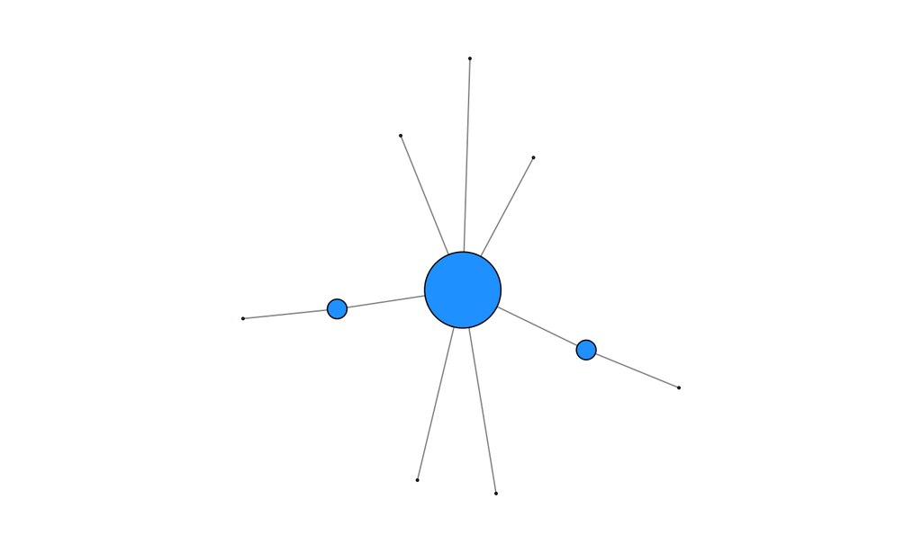

## Node-level measures

**Closeness**:

The inverse of the summed shortest path distance to all other nodes in the network. A form of *centrality*.

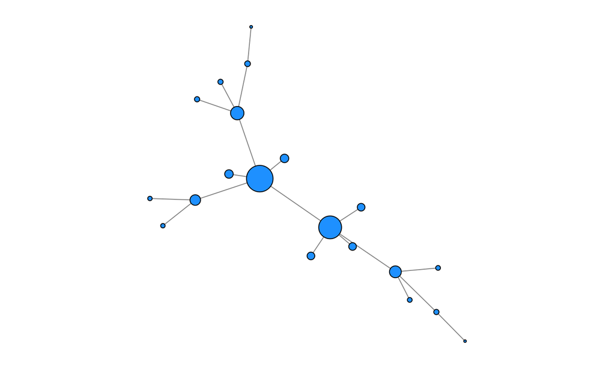

## Node-level measures

**Eigenvector**:

Values of the first eigenvector of the graph adjacency matrix. Tends to define the importance of nodes 1-2 steps removed (how well-linked are your friends?). A form of *centrality*.

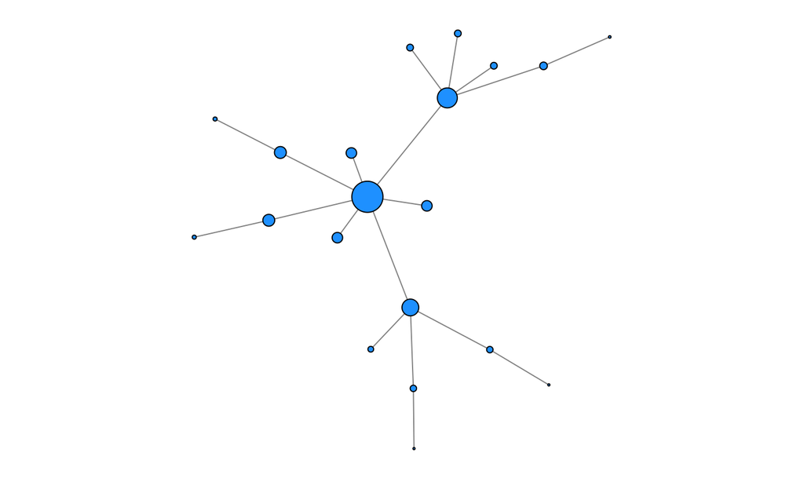

## Centrality

Slightly different measures of the same general idea. Leads to relationships among different types of centrality.

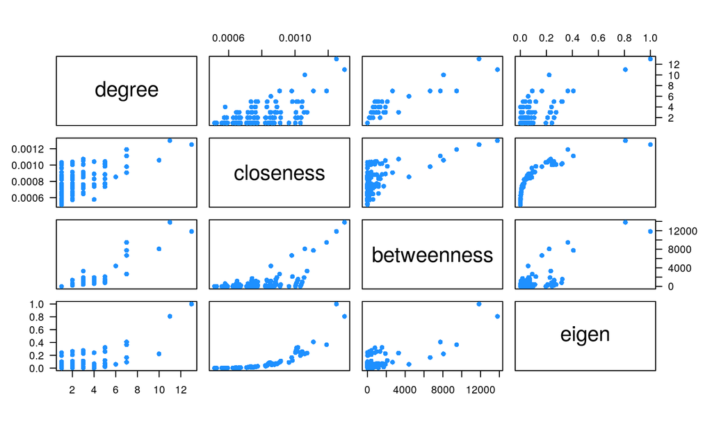

## What are networks good for?

Lots of stuff.

## Recommender systems

Spotify uses *collaborative filtering* to recommend music you might like.

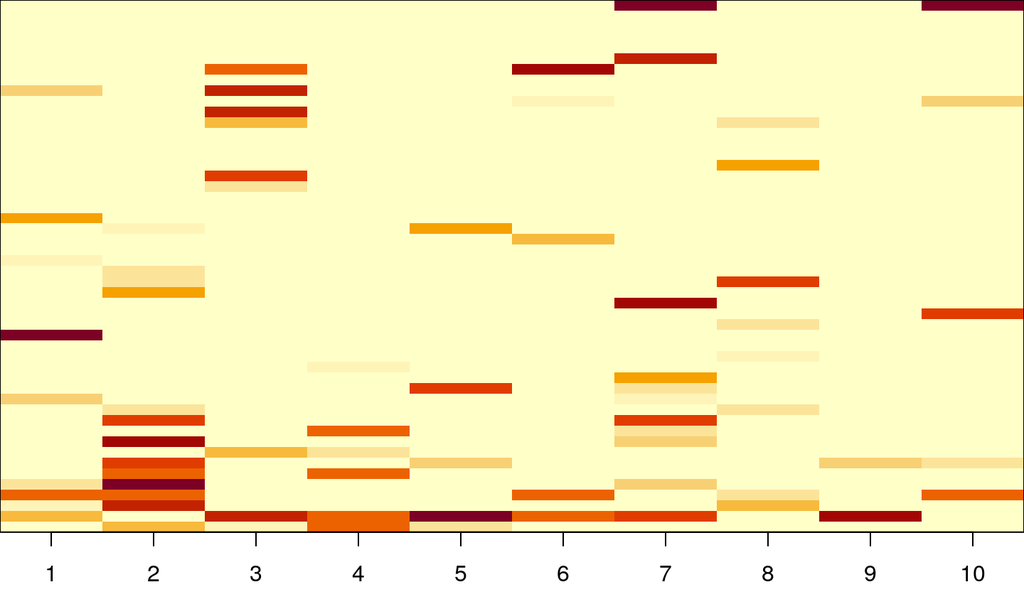

## Missing links

Closely related to recommender systems is the issue of predicting links, either unobserved (host-parasite) or not yet realized (friendship)

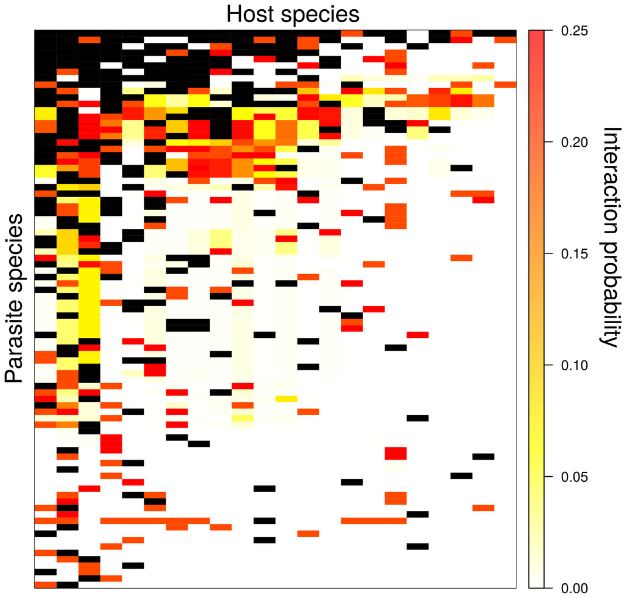

## Gene co-expression networks (WGCNA)

Either unweighted (thresholding of co-expression correlations) or weighted (correlation coefficient defines link weight).

Used to identify clusters of gene co-expression.

Incapable of handling negative correlations, so just takes absolute value and calls it a day.

[figure not shown]

## Vaccination

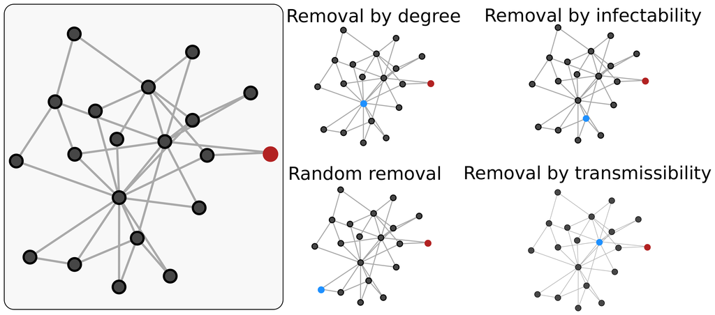

## Contact

https://taddallas.github.io

tadallas@lsu.edu

## Designing robust systems

Error and attack tolerance in complex networks.

## More stuff

**Clustering coeffiicent**:

The closer the local clustering coefficient is to 1, the more likely it is for the network to form modules.

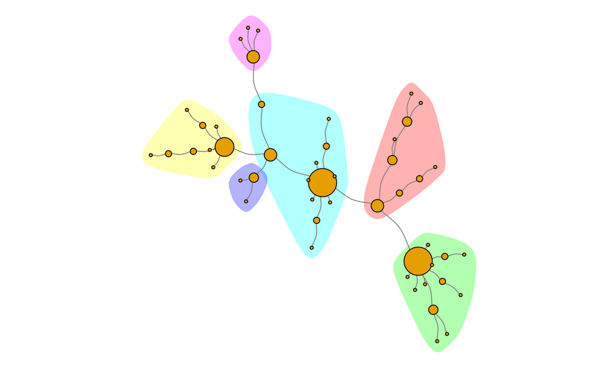